# Untitled

Esther_Wairimu_Kamau

1/21/2021

#### 1.Loading the Packages and Importing the Dataset

I loaded the tidyverse package and the arules package

```r
library(arules)
library(tidyverse)
```

I imported the dataset using the read.transactions() function

```r
# Importing the Dataset

dataset <- read.transactions("http://bit.ly/SupermarketDatasetII" ,sep =",")
```

I used the summary function to obtain the summary statisics of the dataset.

```r
summary(dataset)
```

```
## transactions as itemMatrix in sparse format with
##  7501 rows (elements/itemsets/transactions) and
##  119 columns (items) and a density of 0.03288973
##
## most frequent items:
## mineral water          eggs     spaghetti  french fries     chocolate
##          1788          1348          1306          1282          1229
##       (Other)
##         22405
##
## element (itemset/transaction) length distribution:
## sizes
##    1    2    3    4    5    6    7    8    9   10   11   12   13   14   15   16
## 1754 1358 1044  816  667  493  391  324  259  139  102   67   40   22   17    4
##   18   19   20
##    1    2    1
##
##    Min. 1st Qu.  Median    Mean 3rd Qu.    Max.
##   1.000   2.000   3.000   3.914   5.000  20.000
##
## includes extended item information - examples:
##              labels
## 1           almonds
## 2 antioxydant juice
## 3         asparagus
```

The dataset had 119 items with 7501 itemsets with the most frequently purchased item being mineral water.

I then previewed the first ten itemsets using the inspect function

```r
inspect(dataset[1:10])
```

```
##      items
## [1]  {almonds,
##       antioxydant juice,
##       avocado,
##       cottage cheese,
##       energy drink,
##       frozen smoothie,
##       green grapes,
##       green tea,
##       honey,
##       low fat yogurt,
##       mineral water,
##       olive oil,
##       salad,
##       salmon,
##       shrimp,
##       spinach,
##       tomato juice,
##       vegetables mix,
##       whole weat flour,
##       yams}
## [2]  {burgers,
##       eggs,
##       meatballs}
## [3]  {chutney}
## [4]  {avocado,
##       turkey}
## [5]  {energy bar,
##       green tea,
##       milk,
##       mineral water,
##       whole wheat rice}
## [6]  {low fat yogurt}
## [7]  {french fries,
##       whole wheat pasta}
## [8]  {light cream,
##       shallot,
##       soup}
## [9]  {frozen vegetables,
##       green tea,
##       spaghetti}
## [10] {french fries}
```

```r
# we previewed the labels of the items in my dataset.
items <- as.data.frame(itemLabels(dataset))
colnames(items) <- "Item"
head(items, 10)
```

```
##                 Item
## 1            almonds
## 2  antioxydant juice
## 3          asparagus
## 4            avocado
## 5        babies food
## 6              bacon
## 7     barbecue sauce
## 8          black tea
## 9        blueberries
## 10        body spray
```

```r
tail(items,10)
```

```
##                  Item
## 110            turkey
## 111    vegetables mix
## 112       water spray
## 113        white wine
## 114  whole weat flour
## 115 whole wheat pasta
## 116  whole wheat rice
## 117              yams
## 118       yogurt cake
## 119          zucchini
```

```r
#checked the frequency of first 15 labels
itemFrequency(dataset[, 1:15],type = "absolute")
```

```
##           almonds antioxydant juice         asparagus           avocado
##               153                67                36               250
##       babies food             bacon    barbecue sauce         black tea
##                34                65                81               107
##       blueberries        body spray           bramble          brownies
##                69                86                14               253
##         bug spray      burger sauce           burgers
##                65                44               654
```

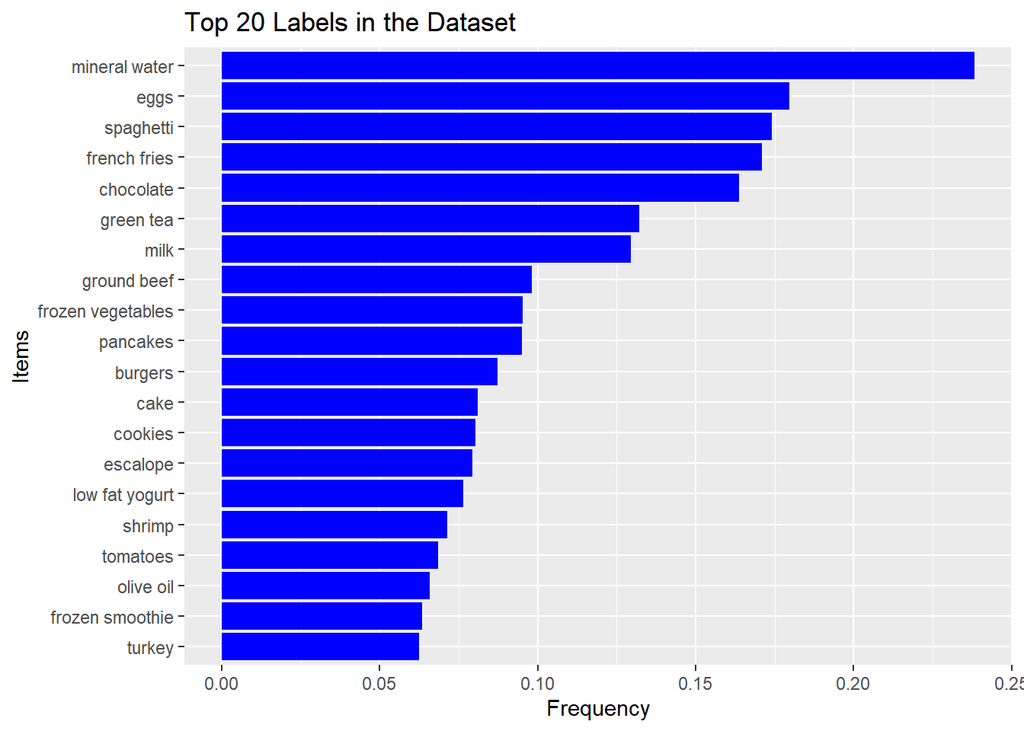

```r
#we plotted 20 most frequent items in the dataset using the ItemFrequency and topN.
itemFrequencyGGPlot <- function(x, topN) {
  library(tidyverse)
  x %>%
    itemFrequency %>%
    sort %>%
    tail(topN) %>%
    as.data.frame %>%
    tibble::rownames_to_column() %>%
    ggplot(aes(reorder(rowname, `.`),`.`)) +
    geom_col(fill='blue') + labs(title='Top 20 Labels in the Dataset' , y  = "Frequency" , x = 'Items')+
    coord_flip()
}
itemFrequencyGGPlot(dataset, 20)
```

We observed that The most frequent label within the whole dataset was the Mineral water , followed by eggs.

#### 2.Association Rules

```r
#checked the rules of the dataset using the apriori()  function.
rules <- apriori (dataset, parameter = list(supp = 0.001, conf = 0.8))
```

```
## Apriori
##
## Parameter specification:
##  confidence minval smax arem  aval originalSupport maxtime support minlen
##         0.8    0.1    1 none FALSE            TRUE       5   0.001      1
##  maxlen target  ext
##      10  rules TRUE
##
## Algorithmic control:
##  filter tree heap memopt load sort verbose
##     0.1 TRUE TRUE  FALSE TRUE    2    TRUE
##
## Absolute minimum support count: 7
##
## set item appearances ...[0 item(s)] done [0.00s].
## set transactions ...[119 item(s), 7501 transaction(s)] done [0.01s].
## sorting and recoding items ... [116 item(s)] done [0.00s].
## creating transaction tree ... done [0.01s].
## checking subsets of size 1 2 3 4 5 6 done [0.01s].
## writing ... [74 rule(s)] done [0.00s].
## creating S4 object  ... done [0.00s].
```

```r
rules
```

```
## set of 74 rules
```

we set support as at 0.001 and my confidence as 0.8 , I got 74 rules from the dataset

we used the inspect function to see the first 10 rules of my dataset

```r
inspect(rules[1:10])
```

```
##      lhs                             rhs             support     confidence
## [1]  {frozen smoothie,spinach}    => {mineral water} 0.001066524 0.8888889
## [2]  {bacon,pancakes}             => {spaghetti}     0.001733102 0.8125000
## [3]  {nonfat milk,turkey}         => {mineral water} 0.001199840 0.8181818
## [4]  {ground beef,nonfat milk}    => {mineral water} 0.001599787 0.8571429
## [5]  {mushroom cream sauce,pasta} => {escalope}      0.002532996 0.9500000
## [6]  {milk,pasta}                 => {shrimp}        0.001599787 0.8571429
## [7]  {cooking oil,fromage blanc}  => {mineral water} 0.001199840 0.8181818
## [8]  {black tea,salmon}           => {mineral water} 0.001066524 0.8000000
## [9]  {black tea,frozen smoothie}  => {milk}          0.001199840 0.8181818
## [10] {red wine,tomato sauce}      => {chocolate}     0.001066524 0.8000000
##      coverage    lift      count
## [1]  0.001199840  3.729058  8
## [2]  0.002133049  4.666587 13
## [3]  0.001466471  3.432428  9
## [4]  0.001866418  3.595877 12
## [5]  0.002666311 11.976387 19
## [6]  0.001866418 11.995203 12
## [7]  0.001466471  3.432428  9
## [8]  0.001333156  3.356152  8
## [9]  0.001466471  6.313973  9
## [10] 0.001333156  4.882669  8
```

We Interpretate the first rule: as If someone buys frozen smoothie and spinach, they are 89% likely to buy mineral water.

#### 3. Visualizing association rules using the arulesviz package

```r
#install.packages("arulesViz")
library(arulesViz)
subrules <- head(rules, n = 10, by = "confidence")


plot(subrules, method = "graph" ,   engine = "htmlwidget")
```

[interactive chart not shown]

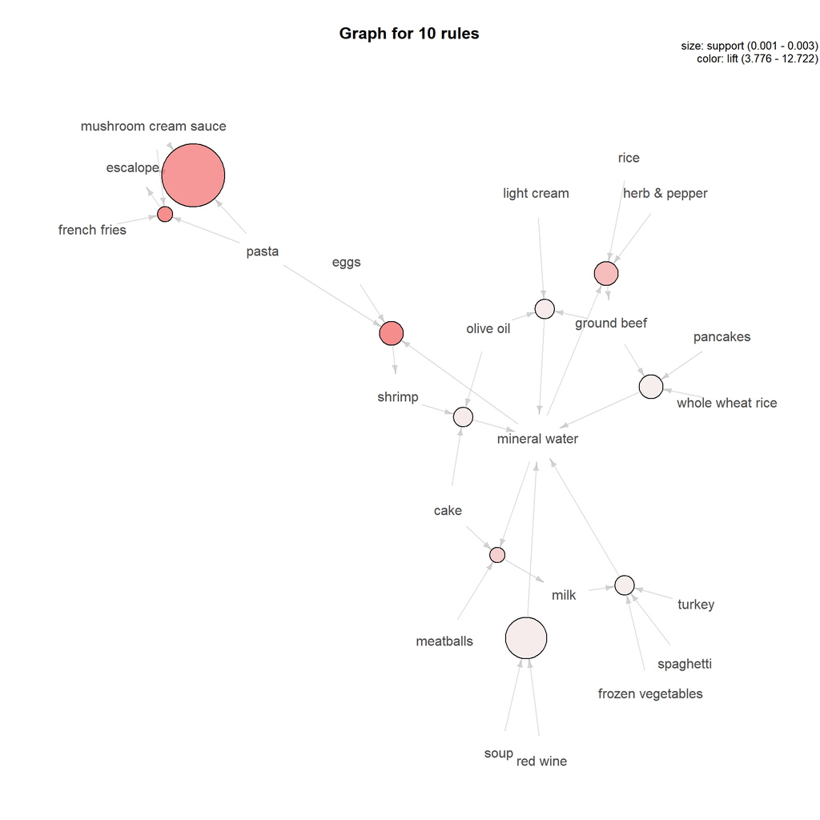

```r
plot(subrules, method = "graph" ,   engine = "default")
```

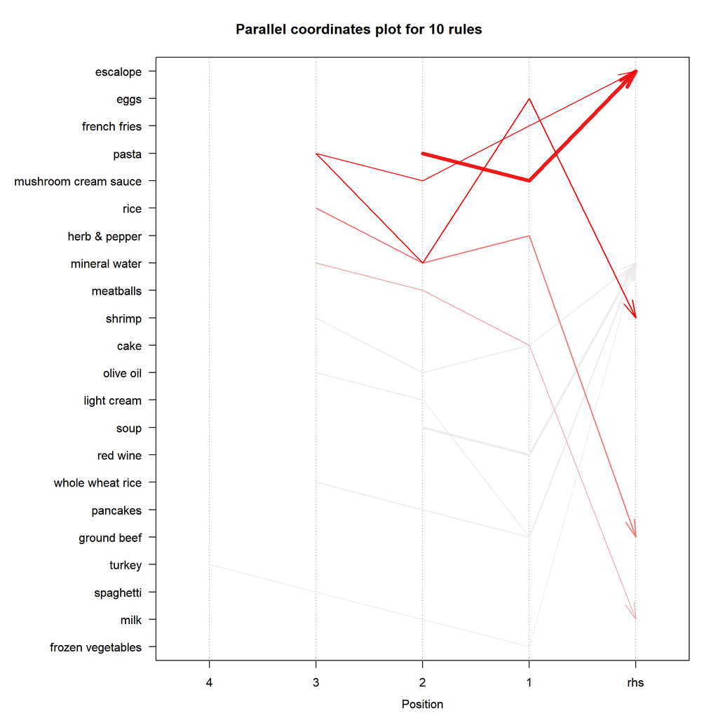

```r
plot(subrules, method = "paracoord")
```

we can observe all the connections mineral water has with the other commodities

```r
# If we wanted to preview the items that make up our dataset,
# alternatively we can do the following
# ---
#
items<-as.data.frame(itemLabels(dataset))
colnames(items) <- "Item"
head(items, 10)
```

```
##                 Item
## 1            almonds
## 2  antioxydant juice
## 3          asparagus
## 4            avocado
## 5        babies food
## 6              bacon
## 7     barbecue sauce
## 8          black tea
## 9        blueberries
## 10        body spray
```

```r
# Generating a summary of the transaction dataset
# ---
# This would give us some information such as the most purchased items,
# distribution of the item sets (no. of items purchased in each transaction), etc.
# ---
#
summary(dataset)
```

```
## transactions as itemMatrix in sparse format with
##  7501 rows (elements/itemsets/transactions) and
##  119 columns (items) and a density of 0.03288973
##
## most frequent items:
## mineral water          eggs     spaghetti  french fries     chocolate
##          1788          1348          1306          1282          1229
##       (Other)
##         22405
##
## element (itemset/transaction) length distribution:
## sizes
##    1    2    3    4    5    6    7    8    9   10   11   12   13   14   15   16
## 1754 1358 1044  816  667  493  391  324  259  139  102   67   40   22   17    4
##   18   19   20
##    1    2    1
##
##    Min. 1st Qu.  Median    Mean 3rd Qu.    Max.
##   1.000   2.000   3.000   3.914   5.000  20.000
##
## includes extended item information - examples:
##              labels
## 1           almonds
## 2 antioxydant juice
## 3         asparagus
```

```r
# Exploring the frequency of some articles
# i.e. transacations ranging from 1 to 10 and performing
# some operation in percentage terms of the total transactions
#
Tr<-dataset
itemFrequency(Tr[, 1:10],type = "absolute")
```

```
##           almonds antioxydant juice         asparagus           avocado
##               153                67                36               250
##       babies food             bacon    barbecue sauce         black tea
##                34                65                81               107
##       blueberries        body spray
##                69                86
```

```r
round(itemFrequency(Tr[, 1:10],type = "relative")*100,2)
```

```
##           almonds antioxydant juice         asparagus           avocado
##              2.04              0.89              0.48              3.33
##       babies food             bacon    barbecue sauce         black tea
##              0.45              0.87              1.08              1.43
##       blueberries        body spray
##              0.92              1.15
```

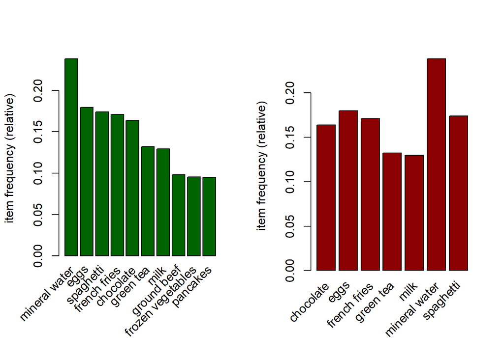

```r
# Producing a chart of frequencies and fitering
# to consider only items with a minimum percentage
# of support/ considering a top x of items
# ---
# Displaying top 10 most common items in the transactions dataset
# and the items whose relative importance is at least 10%
#
par(mfrow = c(1, 2))

# plot the frequency of items
itemFrequencyPlot(Tr, topN = 10,col="darkgreen")
itemFrequencyPlot(Tr, support = 0.1,col="darkred")
```

#### 3.Trying another confidence Interval

```r
# Building a model based on association rules
# using the apriori function
# ---
# We use Min Support as 0.001 and confidence as 0.8
# ---
#
rules1 <- apriori (Tr, parameter = list(supp = 0.001, conf = 0.9))
```

```
## Apriori
##
## Parameter specification:
##  confidence minval smax arem  aval originalSupport maxtime support minlen
##         0.9    0.1    1 none FALSE            TRUE       5   0.001      1
##  maxlen target  ext
##      10  rules TRUE
##
## Algorithmic control:
##  filter tree heap memopt load sort verbose
##     0.1 TRUE TRUE  FALSE TRUE    2    TRUE
##
## Absolute minimum support count: 7
##
## set item appearances ...[0 item(s)] done [0.00s].
## set transactions ...[119 item(s), 7501 transaction(s)] done [0.00s].
## sorting and recoding items ... [116 item(s)] done [0.00s].
## creating transaction tree ... done [0.00s].
## checking subsets of size 1 2 3 4 5 6 done [0.01s].
## writing ... [11 rule(s)] done [0.00s].
## creating S4 object  ... done [0.00s].
```

```r
rules1
```

```
## set of 11 rules
```

we set support as at 0.001 and my confidence as 0.9 , I got 11 rules from the dataset

we used the inspect function to see the first 5 rules of my dataset

```r
# We use measures of significance and interest on the rules,
# determining which ones are interesting and which to discard.
# ---
# However since we built the model using 0.001 Min support
# and confidence as 0.8 we obtained 410 rules.
# However, in order to illustrate the sensitivity of the model to these two parameters,
# we will see what happens if we increase the support or lower the confidence level
# Building a apriori model with Min Support as 0.002 and confidence as 0.8.

rules2 <- apriori (Tr,parameter = list(supp = 0.002, conf = 0.8))
```

```
## Apriori
##
## Parameter specification:
##  confidence minval smax arem  aval originalSupport maxtime support minlen
##         0.8    0.1    1 none FALSE            TRUE       5   0.002      1
##  maxlen target  ext
##      10  rules TRUE
##
## Algorithmic control:
##  filter tree heap memopt load sort verbose
##     0.1 TRUE TRUE  FALSE TRUE    2    TRUE
##
## Absolute minimum support count: 15
##
## set item appearances ...[0 item(s)] done [0.00s].
## set transactions ...[119 item(s), 7501 transaction(s)] done [0.01s].
## sorting and recoding items ... [115 item(s)] done [0.00s].
## creating transaction tree ... done [0.00s].
## checking subsets of size 1 2 3 4 5 done [0.00s].
## writing ... [2 rule(s)] done [0.00s].
## creating S4 object  ... done [0.00s].
```

```r
rules2
```

```
## set of 2 rules
```

we observe 2rules

```r
# Building apriori model with Min Support as 0.001 and confidence as 0.6.

rules3 <- apriori (Tr, parameter = list(supp = 0.001, conf = 0.6))
```

```
## Apriori
##
## Parameter specification:
##  confidence minval smax arem  aval originalSupport maxtime support minlen
##         0.6    0.1    1 none FALSE            TRUE       5   0.001      1
##  maxlen target  ext
##      10  rules TRUE
##
## Algorithmic control:
##  filter tree heap memopt load sort verbose
##     0.1 TRUE TRUE  FALSE TRUE    2    TRUE
##
## Absolute minimum support count: 7
##
## set item appearances ...[0 item(s)] done [0.00s].
## set transactions ...[119 item(s), 7501 transaction(s)] done [0.01s].
## sorting and recoding items ... [116 item(s)] done [0.00s].
## creating transaction tree ... done [0.00s].
## checking subsets of size 1 2 3 4 5 6 done [0.01s].
## writing ... [545 rule(s)] done [0.00s].
## creating S4 object  ... done [0.00s].
```

```r
rules3
```

```
## set of 545 rules
```

```r
# We can perform an exploration of our model
# through the use of the summary function as shown
# ---
# Upon running the code, the function would give us information about the model
# i.e. the size of rules, depending on the items that contain these rules.
# In our above case, most rules have 3 and 4 items though some rules do have upto 6.
# More statistical information such as support, lift and confidence is also provided.
# ---
#
summary(rules)
```

```
## set of 74 rules
##
## rule length distribution (lhs + rhs):sizes
##  3  4  5  6
## 15 42 16  1
##
##    Min. 1st Qu.  Median    Mean 3rd Qu.    Max.
##   3.000   4.000   4.000   4.041   4.000   6.000
##
## summary of quality measures:
##     support           confidence        coverage             lift
##  Min.   :0.001067   Min.   :0.8000   Min.   :0.001067   Min.   : 3.356
##  1st Qu.:0.001067   1st Qu.:0.8000   1st Qu.:0.001333   1st Qu.: 3.432
##  Median :0.001133   Median :0.8333   Median :0.001333   Median : 3.795
##  Mean   :0.001256   Mean   :0.8504   Mean   :0.001479   Mean   : 4.823
##  3rd Qu.:0.001333   3rd Qu.:0.8889   3rd Qu.:0.001600   3rd Qu.: 4.877
##  Max.   :0.002533   Max.   :1.0000   Max.   :0.002666   Max.   :12.722
##      count
##  Min.   : 8.000
##  1st Qu.: 8.000
##  Median : 8.500
##  Mean   : 9.419
##  3rd Qu.:10.000
##  Max.   :19.000
##
## mining info:
##     data ntransactions support confidence
##  dataset          7501   0.001        0.8
```

```r
# Observing rules built in our model i.e. first 5 model rules
# ---
#
inspect(rules1[1:5])
```

```
##     lhs                                          rhs             support
## [1] {mushroom cream sauce,pasta}              => {escalope}      0.002532996
## [2] {red wine,soup}                           => {mineral water} 0.001866418
## [3] {french fries,mushroom cream sauce,pasta} => {escalope}      0.001066524
## [4] {eggs,mineral water,pasta}                => {shrimp}        0.001333156
## [5] {ground beef,light cream,olive oil}       => {mineral water} 0.001199840
##     confidence coverage    lift      count
## [1] 0.9500000  0.002666311 11.976387 19
## [2] 0.9333333  0.001999733  3.915511 14
## [3] 1.0000000  0.001066524 12.606723  8
## [4] 0.9090909  0.001466471 12.722185 10
## [5] 1.0000000  0.001199840  4.195190  9
```

```r
# Interpretation of the first rule:
# ---
# If someone buys frozen smoothie and spinach, they are 88% likely to buy mineral water  too
# ---
```

We Interpretate the first rule: as If someone buys mushroom cream sauce and pasta, they are 95% likely to buy escalope

```r
# Observing rules built in our model i.e. first 2 model rules
# ---
#

inspect(rules2[1:2])
```

```
##     lhs                                       rhs         support
## [1] {mushroom cream sauce,pasta}           => {escalope}  0.002532996
## [2] {frozen vegetables,olive oil,tomatoes} => {spaghetti} 0.002133049
##     confidence coverage    lift      count
## [1] 0.9500000  0.002666311 11.976387 19
## [2] 0.8421053  0.002532996  4.836624 16
```

- Interpretation of the first rule:If someone buys mushroom cream sauce and pasta, they are 95% likely to buy escalope too
- Interpretation of the second rule:If someone buys frozen vegetables,olive oil and tomatoes, they are 84% likely to buy spaghetti too